# Lecture 2: Computer Methods for Solving Linear Systems of Equations

Author

Joong-Ho Won

Published

March 2026

[session information not shown]

**Code Output**

[session information not shown]

```r
library(Matrix)
```

## Introduction

We consider computer algorithms for solving linear equations $\mathbf{A} \mathbf{x} = \mathbf{b}$, a ubiquitous task in statistics.

### Our mantra

> **The form of a mathematical expression and the way the expression should be evaluated in actual practice may be quite different.**  
> – James Gentle, *Matrix Algebra*, Springer, New York (2007).

## Algorithms

- Algorithm is loosely defined as a set of instructions for doing something, which terminates in finite time. An algorithm requires input and output.

### Measure of algorithm efficiency

- A basic unit for measuring algorithmic efficiency is **flop**.
  - A flop (**floating point operation**) consists of a floating point addition, subtraction, multiplication, division, or comparison, and the usually accompanying fetch and store.
- How to measure efficiency of an algorithm? Big O notation. If $n$ is the size of a problem, an algorithm has order $O(f(n))$, where the leading term in the number of flops is $c \cdot f(n)$. For example,
  - matrix-vector multiplication `A * b`, where `A` is $m \times n$ and `b` is $n \times 1$, takes $2mn$ or $O(mn)$ flops
  - matrix-matrix multiplication `A * B`, where `A` is $m \times n$ and `B` is $n \times p$, takes $2mnp$ or $O(mnp)$ flops
- Typical orders of computational complexity:
  - Exponential order: $O(b^n)$ (“horrible”)
  - Polynomial order: $O(n^q)$ (doable)
  - $O(n \log n )$ (fast)
  - Linear order $O(n)$ (fast)
  - Logarithmic order $O(\log n)$ (super fast)
- Difference of $O(n^2)$ and $O(n\log n)$ on massive data. Suppose we have a teraflops supercomputer capable of doing $10^{12}$ flops per second. For a problem of size $n=10^{12}$, $O(n \log n)$ algorithm takes about
  $$10^{12} \log (10^{12}) / 10^{12} \approx 27 \text{ seconds}.$$
  $O(n^2)$ algorithm takes about $10^{12}$ seconds, which is approximately 31710 years!
- The Quicksort and Fast Fourier Transform (invented by John Tukey–recall “bit”–) are celebrated algorithms that turn $O(n^2)$ operations into $O(n \log n)$.

# Triangular systems

Idea: turning original problem into an **easy** one, e.g., triangular system.

## Lower triangular system

To solve $\mathbf{A} \mathbf{x} = \mathbf{b}$, where $\mathbf{A} \in \mathbb{R}^{n \times n}$ is **lower triangular**

$$\begin{bmatrix}
a_{11} & 0 & \cdots & 0 \\
a_{21} & a_{22} & \cdots & 0 \\
\vdots & \vdots & \ddots & \vdots \\
a_{n1} & a_{n2} & \cdots & a_{nn}
\end{bmatrix}
\begin{bmatrix}
x_1 \\ x_2 \\ \vdots \\ x_n
\end{bmatrix} = \begin{bmatrix}
b_1 \\ b_2 \\ \vdots \\ b_n
\end{bmatrix}.$$

- **Forward substitution**:
  $$\begin{eqnarray*}
  x_1 &=& b_1 / a_{11} \\
  x_2 &=& (b_2 - a_{21} x_1) / a_{22} \\
  x_3 &=& (b_3 - a_{31} x_1 - a_{32} x_2) / a_{33} \\
  &\vdots& \\
  x_n &=& (b_n - a_{n1} x_1 - a_{n2} x_2 - \cdots - a_{n,n-1} x_{n-1}) / a_{nn}.
  \end{eqnarray*}$$
- $1 + 3 + 5 + \cdots + (2n-1) = n^2$ flops.

## Upper triangular system

To solve $\mathbf{A} \mathbf{x} = \mathbf{b}$, where $\mathbf{A} \in \mathbb{R}^{n \times n}$ is upper triangular
$$\begin{bmatrix}
a_{11} & \cdots & a_{1,n-1} & a_{1n} \\
\vdots & \ddots & \vdots & \vdots \\
0 & \cdots & a_{n-1,n-1} & a_{n-1,n} \\
0 & 0 & 0 & a_{nn}
\end{bmatrix}
\begin{bmatrix}
x_1 \\ \vdots \\ x_{n-1} \\ x_n
\end{bmatrix} = \begin{bmatrix}
b_1 \\ \vdots \\ b_{n-1} \\ b_n
\end{bmatrix}.$$

- **Back substitution** (backsolve):
  $$\begin{eqnarray*}
  x_n &=& b_n / a_{nn} \\
  x_{n-1} &=& (b_{n-1} - a_{n-1,n} x_n) / a_{n-1,n-1} \\
  x_{n-2} &=& (b_{n-2} - a_{n-2,n-1} x_{n-1} - a_{n-2,n} x_n) / a_{n-2,n-2} \\
  &\vdots& \\
  x_1 &=& (b_1 - a_{12} x_2 - a_{13} x_3 - \cdots - a_{1,n} x_{n}) / a_{11}.
  \end{eqnarray*}$$
- $n^2$ flops.

## Implementation

- Most numerical computing software packages (including R) are built on top of the BLAS (*basic linear algebra subprograms*).
  - [Netlib](http://www.netlib.org/blas/) provides a reference implementation.
  - Vanila R (the binary that you can download from https://www.r-project.org) uses its own implementation of BLAS (see `sessionInfo()` above)
- The BLAS triangular system solve is done *in place*, i.e., $\mathbf{b}$ is **overwritten** by $\mathbf{x}$.

```r
    # forward substitution
    for (i in seq_len(n)) {
        for (j in seq_len(i-1)) {
            b[i] <- b[i] - A[i, j] * b[j]
        }
        b[i] <- b[i] / A[i, i]
    }
    # backsolve
    for (i in rev(seq_len(n))) {
        for (j in i + seq_len(max(n - i, 0))) {
            b[i] <- b[i] - A[i, j] * b[j]
        }
        b[i] <- b[i] / A[i, i]
    }
```

- R
  - `?backsolve`, `?forwardsolve`
  - This is a wrapper for the level-3 BLAS routine [`dtrsm`](http://www.netlib.org/lapack/explore-html/d1/d54/group__double__blas__level3_ga6a0a7704f4a747562c1bd9487e89795c.html#ga6a0a7704f4a747562c1bd9487e89795c)
  - The `d` stands for *double precision*.

```r
set.seed(123) # seed
n <- 5
A <- Matrix(rnorm(n * n), nrow = n)
b <- rnorm(n)
# a random matrix
A
```

**Code Output**

```
5 x 5 Matrix of class "dgeMatrix"
            [,1]       [,2]       [,3]       [,4]       [,5]
[1,] -0.56047565  1.7150650  1.2240818  1.7869131 -1.0678237
[2,] -0.23017749  0.4609162  0.3598138  0.4978505 -0.2179749
[3,]  1.55870831 -1.2650612  0.4007715 -1.9666172 -1.0260044
[4,]  0.07050839 -0.6868529  0.1106827  0.7013559 -0.7288912
[5,]  0.12928774 -0.4456620 -0.5558411 -0.4727914 -0.6250393
```

```r
Al <- lower.tri(A) # Returns a matrix of logicals the same size of a given matrix with entries TRUE in the lower triangle
Aupper <- A
Aupper[Al] <- 0
Aupper
```

**Code Output**

```
5 x 5 Matrix of class "dgeMatrix"
           [,1]      [,2]      [,3]       [,4]       [,5]
[1,] -0.5604756 1.7150650 1.2240818  1.7869131 -1.0678237
[2,]  0.0000000 0.4609162 0.3598138  0.4978505 -0.2179749
[3,]  0.0000000 0.0000000 0.4007715 -1.9666172 -1.0260044
[4,]  0.0000000 0.0000000 0.0000000  0.7013559 -0.7288912
[5,]  0.0000000 0.0000000 0.0000000  0.0000000 -0.6250393
```

```r
backsolve(Aupper, b)
```

**Code Output**

```
[1]  14.623335  22.786164 -22.945749  -3.707499  -2.005978
```

## Some algebraic facts of triangular system

- Eigenvalues of a triangular matrix $\mathbf{A}$ are diagonal entries $\lambda_i = a_{ii}$.
- Determinant $\det(\mathbf{A}) = \prod_i a_{ii}$.
- The product of two upper (lower) triangular matrices is upper (lower) triangular.
- The inverse of an upper (lower) triangular matrix is upper (lower) triangular.
- The product of two unit upper (lower) triangular matrices is unit upper (lower) triangular.
- The inverse of a unit upper (lower) triangular matrix is unit upper (lower) triangular.

# Gaussian Elimination and LU Decomposition

- A toy example.
- History: the method is named after Carl Friedrich Gauss (1777–1855), although it stems from the notes of Isaac Newton. If fact, GE was known to [Chinese mathematicians](https://en.wikipedia.org/wiki/The_Nine_Chapters_on_the_Mathematical_Art) as early as 179 AD.

```r
A <- t(Matrix(c(2.0, -4.0, 2.0, 4.0, -9.0, 7.0, 2.0, 1.0, 3.0), ncol=3))  # R uses column major ordering
A
```

**Code Output**

```
3 x 3 Matrix of class "dgeMatrix"
     [,1] [,2] [,3]
[1,]    2   -4    2
[2,]    4   -9    7
[3,]    2    1    3
```

```r
b <- c(6.0, 20.0, 14.0)
```

```r
# R's way tp solve linear equation

solve(A, b)
```

**Code Output**

```
[1] 2 1 3
```

What happens when we call `solve(A, b)`?

## Elementary operator matrix

- **Elementary operator matrix** is the identity matrix with the 0 in position $(j,k)$ replaced by $c$
  $$\mathbf{E}_{jk}(c) = \begin{bmatrix}
  1 & & \\
  & \ddots & \\
  & & 1 & \\
  & & & \ddots & \\
  & & c & & 1 & \\
  & & & & & \ddots \\
  & & & & & & 1
  \end{bmatrix} = \mathbf{I} + c \mathbf{e}_j \mathbf{e}_k^T.$$
- $\mathbf{E}_{jk}(c)$ is unit triangular, full rank, and its inverse is
  $$\mathbf{E}_{jk}^{-1}(c) = \mathbf{E}_{jk}(-c).$$
- $\mathbf{E}_{jk}(c)$ left-multiplies an $n \times m$ matrix $\mathbf{X}$ effectively replace its $j$-th row $\mathbf{x}_{j\cdot}$ by $c \mathbf{x}_{k \cdot} + \mathbf{x}_{j \cdot}$
  $$\mathbf{E}_{jk}(c) \times \mathbf{X} = \mathbf{E}_{jk}(c) \times \begin{bmatrix}
  & & \\
  \cdots & \mathbf{x}_{k\cdot} & \cdots \\
  & & \\
  \cdots & \mathbf{x}_{j\cdot} & \cdots \\
  & &
  \end{bmatrix} = \begin{bmatrix}
  & & \\
  \cdots & \mathbf{x}_{k\cdot} & \cdots \\
  & & \\
  \cdots & c \mathbf{x}_{k\cdot} + \mathbf{x}_{j\cdot} & \cdots \\
  & &
  \end{bmatrix}.$$
  $2m$ flops (why?).
- Gaussian elimination can be understood as applying a sequence of elementary operator matrices to transform the linear system $\mathbf{A} \mathbf{x} = \mathbf{b}$ to an upper triangular system
  $$\begin{eqnarray*}
  \mathbf{E}_{n,n-1}(c_{n,n-1}) \cdots \mathbf{E}_{21}(c_{21}) \mathbf{A} \mathbf{x} &=& \mathbf{E}_{n,n-1}(c_{n,n-1}) \cdots \mathbf{E}_{21}(c_{21}) \mathbf{b} \\
  \mathbf{U} \mathbf{x} &=& \mathbf{b}_{\text{new}}.
  \end{eqnarray*}$$

Let’s get back to our toy example.

```r
E21 <- t(Matrix(c(1.0, 0.0, 0.0, -2.0, 1.0, 0.0, 0.0, 0.0, 1.0), nrow=3))  # Step 1, inv(L1)
E21
```

**Code Output**

```
3 x 3 sparse Matrix of class "dtCMatrix"

[1,]  1 . .
[2,] -2 1 .
[3,]  . . 1
```

```r
# zero (2, 1) entry
E21 %*% A   # Step 1, A'
```

**Code Output**

```
3 x 3 Matrix of class "dgeMatrix"
     [,1] [,2] [,3]
[1,]    2   -4    2
[2,]    0   -1    3
[3,]    2    1    3
```

```r
E31 <- t(Matrix(c(1.0, 0.0, 0.0, 0.0, 1.0, 0.0, -1.0, 0.0, 1.0), nrow=3))  # Step 2, find the corresponding matrix!
E31
```

**Code Output**

```
3 x 3 sparse Matrix of class "dtCMatrix"

[1,]  1 . .
[2,]  . 1 .
[3,] -1 . 1
```

```r
# zero (3, 1) entry
E31 %*% E21 %*% A  # Step2, A''
```

**Code Output**

```
3 x 3 Matrix of class "dgeMatrix"
     [,1] [,2] [,3]
[1,]    2   -4    2
[2,]    0   -1    3
[3,]    0    5    1
```

```r
E32 <- t(Matrix(c(1.0, 0.0, 0.0, 0.0, 1.0, 0.0, 0.0, 5.0, 1.0), nrow=3))  # Step 3, find the corresponding matrix!
E32
```

**Code Output**

```
3 x 3 sparse Matrix of class "dtCMatrix"

[1,] 1 . .
[2,] . 1 .
[3,] . 5 1
```

```r
# zero (3, 2) entry
E32 %*% E31 %*% E21 %*% A   # Step 3, A'''
```

**Code Output**

```
3 x 3 Matrix of class "dgeMatrix"
     [,1] [,2] [,3]
[1,]    2   -4    2
[2,]    0   -1    3
[3,]    0    0   16
```

Thus we have arrived at an upper triangular matrix $\mathbf{U}$.

## Gauss transformations

- We can combine elementary operations by column.
- For column 1,
  $$\mathbf{M}_1 = \mathbf{E}_{n1}(c_{n1}) \cdots \mathbf{E}_{31}(c_{31}) \mathbf{E}_{21}(c_{21}) = \begin{bmatrix}
  1 & \\
  c_{21} & \\
  & \ddots & \\
  c_{n1} & & 1
  \end{bmatrix}$$
- For column $k$,
  $$\mathbf{M}_k = \mathbf{E}_{nk}(c_{nk}) \cdots \mathbf{E}_{k+1,k}(c_{k+1,k}) = \begin{bmatrix}
  1 & \\
  & \ddots \\
  & & 1 & \\
  & & c_{k+1,k} & 1\\
  & & \vdots & & \ddots \\
  & & c_{n,k} & & & 1
  \end{bmatrix}.$$
- Matrices $\mathbf{M}_1, \ldots, \mathbf{M}_{n-1}$ are called the **Gauss transformations**.

```r
M1 <- E31 %*% E21  # inv(L1 * L2)
M1
```

**Code Output**

```
3 x 3 sparse Matrix of class "dtCMatrix"

[1,]  1 . .
[2,] -2 1 .
[3,] -1 . 1
```

```r
M2 <- E32  # inv(L3)
M2
```

**Code Output**

```
3 x 3 sparse Matrix of class "dtCMatrix"

[1,] 1 . .
[2,] . 1 .
[3,] . 5 1
```

- Gauss transformations $\mathbf{M}_k$ are unit triangular, full rank, with inverse
  $$\mathbf{M}_k^{-1} = \mathbf{E}_{k+1,k}^{-1}(c_{k+1,k}) \cdots \mathbf{E}_{nk}^{-1}(c_{nk}) = \begin{bmatrix}
  1 & \\
  & \ddots \\
  & & 1 & \\
  & & - c_{k+1,k}\\
  & & \vdots & & \ddots \\
  & & - c_{n,k} & & & 1
  \end{bmatrix}.$$

```r
solve(M1)   # L2; solve(A) gives the inverse of A, but use it with caution (see below)
```

**Code Output**

```
3 x 3 sparse Matrix of class "dtCMatrix"

[1,] 1 . .
[2,] 2 1 .
[3,] 1 . 1
```

```r
solve(M2)   # L3
```

**Code Output**

```
3 x 3 sparse Matrix of class "dtCMatrix"

[1,] 1  . .
[2,] .  1 .
[3,] . -5 1
```

## LU decomposition

Gaussian elimination does
$$\mathbf{M}_{n-1} \cdots \mathbf{M}_1 \mathbf{A} = \mathbf{U}.$$
Let

$$\begin{equation*}
\mathbf{L} = \mathbf{M}_1^{-1} \cdots \mathbf{M}_{n-1}^{-1} = \begin{bmatrix}
1 & & & & \\
- c_{21} & \ddots & & & \\
& & 1 & & \\
- c_{k+1,1} & & - c_{k+1,k} & & \\
& & \vdots & & \ddots \\
- c_{n1} & & - c_{nk} & & & 1
\end{bmatrix}.
\end{equation*}$$
Thus we have the **LU decomposition**
$$\mathbf{A} = \mathbf{L} \mathbf{U},$$
where $\mathbf{L}$ is **unit** lower triangular and $\mathbf{U}$ is upper triangular.

- LU decomposition exists if the principal sub-matrix $\mathbf{A}[1:k, 1:k]$ is non-singular for $k=1,\ldots,n-1$.
- If the LU decomposition exists and $\mathbf{A}$ is non-singular, then the LU decmpositon is unique and
  $$\det(\mathbf{A}) = \det(\mathbf{L}) \det(\mathbf{U}) = \prod_{k=1}^n u_{kk}.$$
  - This is basically how R (and MATLAB and Julia) compute determinants.
- The whole LU algorithm is done *in place*, i.e., $\mathbf{A}$ is **overwritten** by $\mathbf{L}$ and $\mathbf{U}$.

```r
for (k in seq_len(n-1)) {
    for (i in k +seq_len(max(n - k, 0))) {
        A[i, k] <- A[i, k] / A[k, k]   # computes L
        for (j in k +seq_len(max(n - k, 0))) {
            A[i, j] <- A[i, j] - A[i, k] * A[k, j]  # computes U
        }
    }
}
```

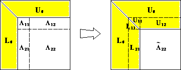

Source: http://www.netlib.org

- The LU decomposition costs (ignoring the cost of division)
  $$2(n-1)^2 + 2(n-2)^2 + \cdots + 2 \cdot 1^2 \approx \frac 23 n^3 \quad \text{flops}.$$
- Given LU decomposition $\mathbf{A} = \mathbf{L} \mathbf{U}$, solving $(\mathbf{L} \mathbf{U}) \mathbf{x} = \mathbf{b}$ for one right hand side costs $2n^2$ flops:
  - One forward substitution ($n^2$ flops) to solve
    $$\mathbf{L} \mathbf{y} = \mathbf{b}$$
  - One back substitution ($n^2$ flops) to solve
    $$\mathbf{U} \mathbf{x} = \mathbf{y}$$
- Therefore to solve $\mathbf{A} \mathbf{x} = \mathbf{b}$ via LU, we need a total of
  $$\frac 23 n^3 + 2n^2 \quad \text{flops}.$$
- If there are multiple right hand sides, LU only needs to be done once.

## Matrix inversion

- For matrix inversion, there are $n$ right hand sides $\mathbf{e}_1, \ldots, \mathbf{e}_n$. Taking advantage of 0s reduces $2n^3$ flops to $\frac 43 n^3$ flops. So **matrix inversion via LU** costs
  $$\frac 23 n^3 + \frac 43 n^3 = 2n^3 \quad \text{flops}.$$
- **No inversion mentality**:  
  > **Whenever we see matrix inverse, we should think in terms of solving linear equations.** > In short, no `solve(A) %*% b`, but `solve(A, b)`.

  We do not compute matrix inverse unless
  1. it is necessary to compute standard errors
  2. number of right hand sides is much larger than $n$
  3. $n$ is small

## Pivoting

- Let
  $$\mathbf{A} = \begin{bmatrix}
  0 & 1 \\
  1 & 0 \\
  \end{bmatrix}.$$
  Is there a solution to $\mathbf{A} \mathbf{x} = \mathbf{b}$ for an arbitrary $\mathbf{b}$? Does GE/LU work for $\mathbf{A}$?
- What if, during LU procedure, the **pivot** $a_{kk}$ is 0 or nearly 0 due to underflow?
  **Example**:
  $$\begin{split}
  0.001x_1 + x_2 &= 1 \\
  x_1 + x_2 &= 2
  \end{split}$$
  with solution

$$\begin{bmatrix} x_1 \\ x_ 2 \end{bmatrix}
=
\begin{bmatrix} 1.001001 \\ 0.998999 \end{bmatrix}
\approx
\begin{bmatrix} 1.0 \\ 1.0 \end{bmatrix}
.$$

- With two significant digits, GE via LU yields
  $$\begin{split}
  0.001x_1 + x_2 &= 1 \\
  (1-1000)x_2 &= 2 - 1000
  \end{split}$$
  or
  $$\begin{split}
  0.001x_1 + x_2 &= 1 \\
  -1000 x_2 &= -1000
  \end{split}
  ,$$
  yielding
  $$\begin{bmatrix} x_1 \\ x_ 2 \end{bmatrix}
  =
  \begin{bmatrix} 0.0 \\ 1.0 \end{bmatrix}
  !$$

### Condition number and stability

- The problem of solving $\mathbf{A}\mathbf{x}=\mathbf{b}$ for fixed $b$ can be viewed as a map $f: \mathbb{R}^{n\times n} \ni \mathbf{A} \mapsto \mathbf{A}^{-1}\mathbf{b} \in \mathbb{R}^n$.
- A *well-conditioned* problem is one such that *all* small perturbations of a given input $\mathbf{A}$ lead to only small changes in $f(\mathbf{A})$.
  - An *ill-conditioned* problem is one such that *some* small perturbation of $\mathbf{A}$ leads to a large change in $f(\mathbf{A})$.
- The conditioning of the problem of computing $\mathbf{A}^{-1}\mathbf{b}$ given $\mathbf{A}$ is usually measured by the **condition number**
  $$\kappa(\mathbf{A}) = \sigma_{\max}(\mathbf{A})/\sigma_{\min}(\mathbf{A})$$
  - $\sigma_{\max}(\mathbf{A}) = \max_{\mathbf{x}\neq 0} \|\mathbf{A}\mathbf{x}\|/\|\mathbf{x}\|$ is the maximum singular value of $\mathbf{A}$;
  - $\sigma_{\min}(\mathbf{A}) = \min_{\mathbf{x}\neq 0} \|\mathbf{A}\mathbf{x}\|/\|\mathbf{x}\|$ is the minimum singular value of $\mathbf{A}$.
- If $\mathbf{A}$ is singular, then $\sigma_{\min}(\mathbf{A}) = 0$, hence $\kappa(\mathbf{A}) = \infty$. So a large condition number indicates that $\mathbf{A}$ is close to singular and the problem is inherently hard.

### Stability

- An *algorithm* for computing $\mathbf{A}^{-1}\mathbf{b}$ using floating-point arithmetric can be viewed as another map $\tilde{f}: \mathbb{R}^{n\times n} \to \mathbb{R}^{n}$.
- For given input $\mathbf{A}$, the solution computed by algorithm $\tilde{f}$ is $\hat{\mathbf{x}} = \tilde{f}(\mathbf{A})$.
  - Example 1: solve $\mathbf{A}\mathbf{x}=\mathbf{b}$ by GE/LU followed by forward and backward substitutions.
  - Example 2: solve $\mathbf{A}\mathbf{x}=\mathbf{b}$ by Gauss-Seidel (an iterative method to come).
- Algorithms will be affected by at least rounding errors.
- Algorithm $\tilde{f}$ is called *stable* if for any perturbed input $\tilde{\mathbf{A}}$ from $\mathbf{A}$ with relative error bounded by $\epsilon$, the relative error between $\hat{\mathbf{x}}$ and $\tilde{\mathbf{A}}^{-1}\mathbf{b}$ is bounded by $O(\epsilon)$.

## Implementation

- Except for the iterative methods, most of these numerical linear algebra tasks are implemented in the BLAS and LAPACK libraries. LAPACK is built on top of BLAS. They form the **building blocks** of most statistical computing tasks.

> LAPACK (Linear Algebra PACKage) is a standard software library for numerical linear algebra. It provides routines for solving systems of linear equations and linear least squares, eigenvalue problems, and singular value decomposition. -[Wikipedia](https://en.wikipedia.org/wiki/LAPACK)
- LAPACK routine [`GETRF`](http://www.netlib.org/lapack/explore-html/dd/d9a/group__double_g_ecomputational_ga0019443faea08275ca60a734d0593e60.html#ga0019443faea08275ca60a734d0593e60) does $\mathbf{P} \mathbf{A} = \mathbf{L} \mathbf{U}$ (LU decomposition with partial pivoting) in place.
- R: `solve()` implicitly performs LU decomposition (wrapper of LAPACK routine `DGESV`). `solve()` allows specifying a single or multiple right hand sides. If none, it computes the matrix inverse. The `Matrix` package contains `lu()` function that outputs `L`, `U`, and `pivot`.

```r
A  # toy example, just to recall
```

**Code Output**

```
3 x 3 Matrix of class "dgeMatrix"
     [,1] [,2] [,3]
[1,]    2   -4    2
[2,]    4   -9    7
[3,]    2    1    3
```

```r
alu <- Matrix::lu(A)
class(alu)
```

**Code Output**

```
[1] "denseLU"
attr(,"package")
[1] "Matrix"
```

```r
ealu <- expand(alu) # expand the decomposition into Factors
```

```r
ealu$L
```

**Code Output**

```
3 x 3 Matrix of class "dtrMatrix" (unitriangular)
     [,1]       [,2]       [,3]
[1,] 1.00000000          .          .
[2,] 0.50000000 1.00000000          .
[3,] 0.50000000 0.09090909 1.00000000
```

```r
ealu$U
```

**Code Output**

```
3 x 3 Matrix of class "dtrMatrix"
     [,1]      [,2]      [,3]
[1,]  4.000000 -9.000000  7.000000
[2,]         .  5.500000 -0.500000
[3,]         .         . -1.454545
```

```r
ealu$P
```

**Code Output**

```
3 x 3 sparse Matrix of class "pMatrix"

[1,] . . |
[2,] | . .
[3,] . | .
```

```r
with(ealu, L %*% U)
```

**Code Output**

```
3 x 3 Matrix of class "dgeMatrix"
     [,1] [,2] [,3]
[1,]    4   -9    7
[2,]    2    1    3
[3,]    2   -4    2
```

```r
with(ealu, P %*% L %*% U)
```

**Code Output**

```
3 x 3 Matrix of class "dgeMatrix"
     [,1] [,2] [,3]
[1,]    2   -4    2
[2,]    4   -9    7
[3,]    2    1    3
```

```r
det(A) # this does LU!
```

**Code Output**

```
[1] -32
```

```r
det(ealu$U) # this is cheap
```

**Code Output**

```
[1] -32
```

```r
solve(A) # this does LU!
```

**Code Output**

```
3 x 3 Matrix of class "dgeMatrix"
        [,1]    [,2]   [,3]
[1,]  1.0625 -0.4375 0.3125
[2,] -0.0625 -0.0625 0.1875
[3,] -0.6875  0.3125 0.0625
```

```r
with(ealu, solve(U) %*% solve(L) %*% t(P) ) # this is cheap???
```

**Code Output**

```
3 x 3 Matrix of class "dgeMatrix"
        [,1]    [,2]   [,3]
[1,]  1.0625 -0.4375 0.3125
[2,] -0.0625 -0.0625 0.1875
[3,] -0.6875  0.3125 0.0625
```